# Analysis of Initial Small Subset of Cell Stress Compounds

This Notebook serves as a way to follow the analysis steps and decide what to take forward to the full investigation.

#### Load Packages

```r
library(ggplot2)
library(ComplexHeatmap)
library(org.Hs.eg.db)
library(ReactomePA)
library(qusage)
library(dendextend)
library(gplots)
library(tidyverse)
library(corrr)
library(igraph)
library(ggraph)
library(tidygraph)
```

#### Analysis of CARNIVAL results

CARNIVAL results are subnetworks which we can use to perform enrichment and similarity analyses.

First we can perform enrichment analyses to see which pathways or cell stress mechanisms are inferred to be differentially regulated based on the dysregulated signalling proteins reasoned using a PPI network and the above gene expression data.

I first create a simple function to perform enrichment of an input gmt file

```r
enrichGMT = function(gmt_file,inferred_proteins,net_proteins){

  gmt_read = read.gmt(gmt_file)

  all_results = list()
  for(i in 1:length(gmt_read)){
    gene_set_name = names(gmt_read[i])
    gene_set = gmt_read[[i]]


    a = intersect(gene_set,inferred_proteins)
    b = setdiff(gene_set,inferred_proteins)
    c = setdiff(inferred_proteins,gene_set)
    d = setdiff(net_proteins,c(a,b,c))

    mat = matrix(data=c(length(a),length(b),length(c),length(d)),nrow=2,ncol=2)

    enrich = fisher.test(mat,alternative="greater")$p.value

    res = c(gene_set_name,paste0(a,collapse=", "),enrich)

    all_results[[i]] = t(data.frame(res))
  }

  results_df = data.frame(do.call("rbind",all_results))
  rownames(results_df) = NULL
  colnames(results_df) = c("Gene set", "Overlap", "pValue")
  results_df$pAdj = p.adjust(as.numeric(as.character(results_df$pValue)))

  return(results_df)
}
```

```r
# Get full network for background enrichment
net = read.csv("../Network_Data/omnipath_full_formatted.csv")
net_proteins = unique(c(as.character(net$source)),as.character(net$target))
universe = AnnotationDbi::select(keys=net_proteins,
                        org.Hs.eg.db,
                        columns=c("SYMBOL","ENTREZID"),
                        keytype="SYMBOL"
                        )$ENTREZID

# List directories
carnival_res_dirs = list.dirs("../Results/CARNIVAL",full.names = T)
carnival_res_dirs = carnival_res_dirs[2:50] # get rid of root dir

# Loop over dirs
for(dir in carnival_res_dirs){

  # Network is contained in .dot file
  dot_file = list.files(path=dir,pattern=".dot",full.names = T)
  read_in_file = read.table(dot_file,sep="\t")

  # Extract network (contains "->")
  dot_net = data.frame(grep(("->"),read_in_file$V1,value=T))
  colnames(dot_net) = "V1"

  # Now format it as .sif format for Cytoscape viz later
  split_net = data.frame(do.call('rbind',strsplit(as.character(dot_net$V1),'->',fixed=T)))

  # make a col with "activates" or "inactivates" based on 'tee' or 'vee' being present in the 'arrowhead' param
  split_net$X3 = ifelse(grepl("tee",split_net$X2),"inhibits","activates")

  # get rid of []
  split_net$X2 = gsub("\\[.*?\\]","",as.character(split_net$X2))

  # reorder cols
  final_net = split_net[c("X1","X3","X2")]
  fname = paste0(dir,"/network.txt")
  write.table(final_net,fname,sep="\t",quote = F,row.names = F)

  # Now get annotations, get activation state based on fill colour
  dot_anno = data.frame(grep(("fillcolor"),read_in_file$V1,value=T))
  colnames(dot_anno) = "V1"
  dot_anno$V2 = ifelse(grepl("mistyrose",dot_anno$V1),"-1","+1")
  # get rid of []
  dot_anno$V1 = gsub("\\[.*?\\]","",as.character(dot_anno$V1))
  dot_anno$V1 = gsub(" ;","",as.character(dot_anno$V1))
  fname = paste0(dir,"/anno.txt")
  write.table(dot_anno,fname,sep="\t",quote=F,row.names=F)

  # Extract signalling proteins
  inferred_proteins = unique(c(as.character(final_net$X1),as.character(final_net$X2)))

  # Convert to Entrez id
  conversion = AnnotationDbi::select(keys=inferred_proteins,
                        org.Hs.eg.db,
                        columns=c("SYMBOL","ENTREZID"),
                        keytype="SYMBOL"
                        )$ENTREZID

  # Do the enrichment of Reactome pathways
  enrichment = enrichPathway(conversion,
                organism="human",
                universe=universe,
                readable=T)

  # Save table
  fname = paste0(dir,"/reactome_enrichment.csv")
  write.csv(enrichment@result,fname)

  # Do the enrichment of the curated gene sets
  gmt_file = "../../gmt/allsigthdd_10282020.gmt"
  allsigthdd_res = enrichGMT(gmt_file,inferred_proteins,net_proteins)
  fname = paste0(dir,"/allsigthdd_enrichment.csv")
  write.csv(allsigthdd_res,fname)

  gmt_file = "../../gmt/EXPERIMENTAL_directional_consensus_signatures_V1_EXPERIMENTAL.gmt"
  experimental_res = enrichGMT(gmt_file,inferred_proteins,net_proteins)
  fname = paste0(dir,"/experimental_enrichment.csv")
  write.csv(experimental_res,fname)

  gmt_file = "../../gmt/nondirectional_consensus_signatures_V1_20200807.gmt"
  nondirectional_res = enrichGMT(gmt_file,inferred_proteins,net_proteins)
  fname = paste0(dir,"/nondirectional_enrichment.csv")
  write.csv(nondirectional_res,fname)
}
```

Now that we have the enrichment results we can compare the output networks based on (a) enrichment (b) presence of nodes In theory, compounds which induce similar cell stress responses will have similar enriched pathways and nodes in the networks.

First we can perform a Jaccard coefficient analysis of networks, where higher Jaccard coefficient = more similar networks, and can thus be inferred to induce a similar response in cellular signalling pathways.

```r
library(RColorBrewer)
# List directories
carnival_res_dirs = list.dirs("../Results/CARNIVAL",full.names = T)
carnival_res_dirs = carnival_res_dirs[2:50] # get rid of root dir

# Pairwise loop over dirs
# NB loop is not very time-efficient but it doesn't take too long
jc_results = data.frame()
for(dir1 in carnival_res_dirs){
  for(dir2 in carnival_res_dirs){

    if(dir1==dir2){ # if same then jc = 1 (diagonal)
      jc = 1
      exp1 = strsplit(dir1,"/")[[1]][4]
      exp2 = strsplit(dir2,"/")[[1]][4]
      # Create row
      row = t(data.frame(c(exp1,exp2,jc)))
      jc_results = rbind(jc_results,row)
      next
    }

    # Network is contained in .sif files
    net_full_1 = read.table(paste0(dir1,"/network.txt"),sep="\t",skip = 1)

    # Extract signalling proteins
    inferred_proteins_1 = unique(c(as.character(net_full_1$V1),as.character(net_full_1$V3)))

    # Network is contained in .sif files
    net_full_2 = read.table(paste0(dir2,"/network.txt"),sep="\t",skip=1)

    # Extract signalling proteins
    inferred_proteins_2 = unique(c(as.character(net_full_2$V1),as.character(net_full_2$V3)))

    # Compute jc
    jc = length(intersect(inferred_proteins_1,inferred_proteins_2))/length(union(inferred_proteins_1,inferred_proteins_2))

    # Get experimental conditions
    exp1 = strsplit(dir1,"/")[[1]][4]
    exp2 = strsplit(dir2,"/")[[1]][4]

    # Create row
    row = t(data.frame(c(exp1,exp2,jc)))
    jc_results = rbind(jc_results,row)
  }
}

# Tidy and save
rownames(jc_results) = NULL
colnames(jc_results) = c("exp1","exp2","Jc")
jc_results$Jc = as.numeric(as.character(jc_results$Jc))
write.csv(jc_results,"../Results/CARNIVAL/network_jaccards.csv")

# Now do the corr mat
# Reshape
jc_results_wide = reshape(jc_results, idvar = "exp1", timevar = "exp2", direction = "wide")
rownames(jc_results_wide) = jc_results_wide$exp1
jc_results_wide$exp1 = NULL
jc_results_wide = as.matrix.data.frame(jc_results_wide)

# Cluster and plot
jc.dist <- as.dist(1 - jc_results_wide) # turn into dissimilarity matrix
tree <- hclust(jc.dist, method="complete") # cluster
dend = as.dendrogram(tree)
color.scheme <- (brewer.pal(10,"Reds")) # generate the color scheme to use
```

```
n too large, allowed maximum for palette Reds is 9
Returning the palette you asked for with that many colors
```

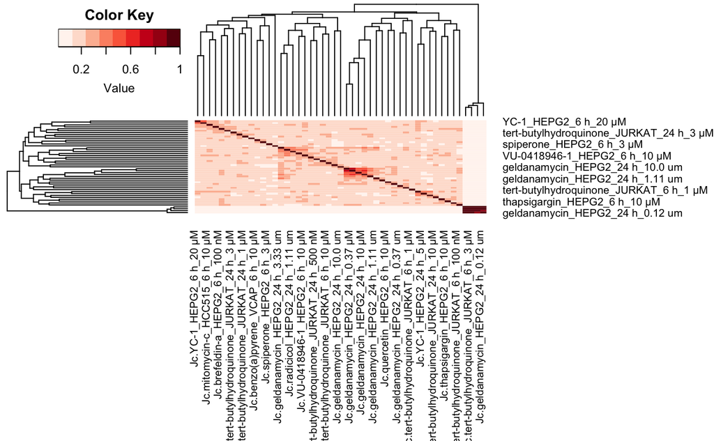

```r
heatmap.2(jc_results_wide,
          Rowv = ladderize(dend),
          Colv = ladderize(dend),
          dendrogram = "both",
          revC = TRUE,  # rev column order of dendrogram so conforms to natural representation
          trace = "none",
          density.info = "none",
          col = color.scheme, key = T,
          margins=c(14,14))
```

Now let’s compare the enrichment results. We will use the custom gene sets rather than the Reactome results, as we mostly care about the cell stress mechanism. We use the same principle as above but instead of computing Jaccard coefficients between two experiment’s network nodes, we are computing correlation coefficients between cell stress mechanism gene sets.

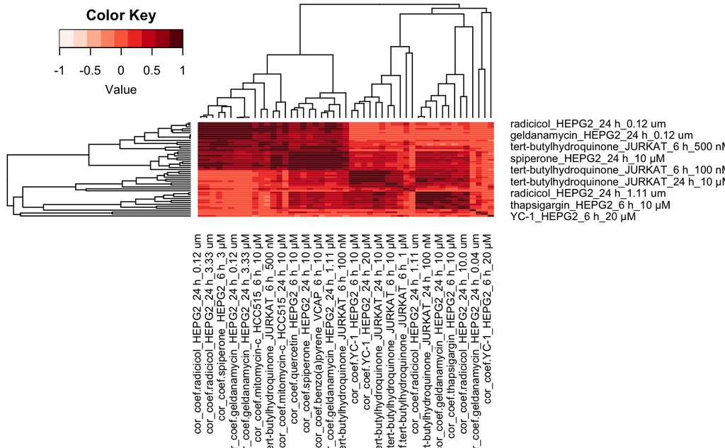

Other analysis can be done as well e.g. time or dose analysis, examining if any particular protein drivers are over-represented in certain cell stress classes, etc.